# Practical Machine Learning Final Project

Olga Ivanova

December 18, 2017

## Background

Based on a data set generously provided by HAR (available at http://groupware.les.inf.puc-rio.br/har) I will try to predict the manner in which users of fitness trackers (i.e.,Jawbone Up, Nike FuelBand, Fitbit etc.) work out and, particularly, how well they do it. This is the “classe” variable in the training set. I will explore the importance as well as the impact of other variables in the training set on the outcome variable by training a prediction model. I will afterwards apply my model to the 20 test cases in the testing data set.

The training data for this project is available here: https://d396qusza40orc.cloudfront.net/predmachlearn/pml-training.csv The testing data for this project is available here: https://d396qusza40orc.cloudfront.net/predmachlearn/pml-testing.csv

To sum up, I will undertake the following steps: 1. Loading data 2. Preprocessing data for future prediction 3. Training prediction model by applying different methods and comparing their accuracy 4. Prediction of the testing data set

## Step 1. Loading data

For building a training model I will be using the following R packages:

```r
library(caret) #v6.0-78
library(rpart) #v4.1-11
library(e1071) #v1.6-8
library(RCurl) #v1.95-4.8
```

```r
library(corrplot) #v.084
library(randomForest) #v.6-12
library(rpart.plot) #v2.1.2
```

First I will load the training and testing data sets:

```r
set.seed(2314)
data.training <- read.csv(url("https://d396qusza40orc.cloudfront.net/predmachlearn/pml-training.csv"))
data.testing <- read.csv(url("https://d396qusza40orc.cloudfront.net/predmachlearn/pml-testing.csv"))
```

Alternatively I can first download data to the current working directory using RCurl package:

```r
setwd("D:/Coursera/PracticalMachineLearning/Project/FinalProject")
URL.training <- "https://d396qusza40orc.cloudfront.net/predmachlearn/pml-training.csv"
URL.testing <- "https://d396qusza40orc.cloudfront.net/predmachlearn/pml-testing.csv"

file.training <- "./data/pml-training.csv"
file.testing <- "./data/pml-testing.csv"

download.file(URL.training, destfile = file.training, method = "libcurl")
download.file(URL.testing, destfile = file.testing, method = "libcurl")
data.training <- read.csv(file.training)
data.testing <- read.csv(file.testing)
```

```r
data.training <- data.training[,-1]
data.testing <- data.testing[,-1]

dim(data.training)
```

```
## [1] 19622   159
```

```r
dim(data.testing)
```

```
## [1]  20 159
```

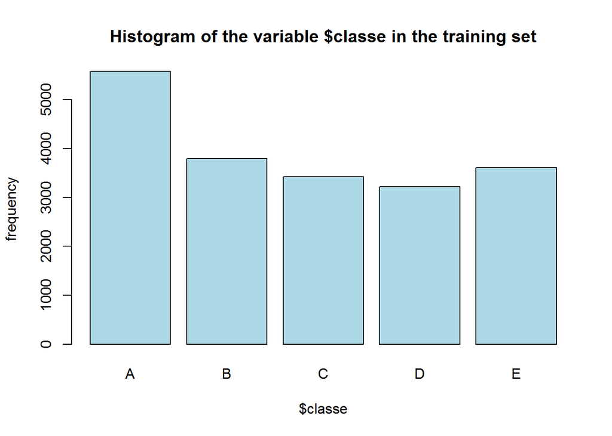

The plot above shows that Level A is the most frequent one. D appears to be the least frequent one.

## Step 2. Preprocessing Data

First, I will remove variables with a near zero variance and eliminate observations with missing values:

```r
nzv <- nearZeroVar(data.training, saveMetrics = T)
head(nzv,10)
```

```
##                      freqRatio percentUnique zeroVar   nzv
## user_name             1.100679    0.03057792   FALSE FALSE
## raw_timestamp_part_1  1.000000    4.26562022   FALSE FALSE
## raw_timestamp_part_2  1.000000   85.53154622   FALSE FALSE
## cvtd_timestamp        1.000668    0.10192641   FALSE FALSE
## new_window           47.330049    0.01019264   FALSE  TRUE
## num_window            1.000000    4.37264295   FALSE FALSE
## roll_belt             1.101904    6.77810621   FALSE FALSE
## pitch_belt            1.036082    9.37722964   FALSE FALSE
## yaw_belt              1.058480    9.97349913   FALSE FALSE
## total_accel_belt      1.063160    0.14779329   FALSE FALSE
```

```r
data.training <- data.training[,!nzv$nzv]
data.testing <- data.testing[,!nzv$nzv]

na <- which(colSums(is.na(data.training)) == F)
data.training <- data.training[,na]
data.testing <- data.testing[,na]

data.training <- data.training[complete.cases(data.training),]
data.testing <- data.testing[complete.cases(data.testing),]
```

Additionaly, I will remove variables in the data set that do not contribute much to the prediction of the outcome variable (i.e., time-related predictors etc.)

```r
removeVars <- grepl("timestamp|user_name|window", names(data.training))
which(removeVars==T)
```

```
## [1] 1 2 3 4 5
```

```r
data.training <- data.training[,!removeVars]
data.testing <- data.testing[,!removeVars]
```

Preprocessing and removing missing values results in a data set with 52 predictors and 1 outcome variable. Next, let us check the correlation between the predictors and figure out whether reducing the number of and/or combining predictors is necessary.

```r
classe_idx <- which(names(data.training) == "classe")
correl <- cor(data.training[, -classe_idx])
highCorrel <- subset(data.frame(as.table(correl)),abs(Freq)>0.6)
head(highCorrel,10)
```

```
##                Var1       Var2       Freq
## 1         roll_belt  roll_belt  1.0000000
## 3          yaw_belt  roll_belt  0.8152297
## 4  total_accel_belt  roll_belt  0.9809241
## 9      accel_belt_y  roll_belt  0.9248983
## 10     accel_belt_z  roll_belt -0.9920085
## 22      accel_arm_y  roll_belt -0.7947807
## 54       pitch_belt pitch_belt  1.0000000
## 55         yaw_belt pitch_belt -0.6997519
## 60     accel_belt_x pitch_belt -0.9657334
## 63    magnet_belt_x pitch_belt -0.8841727
```

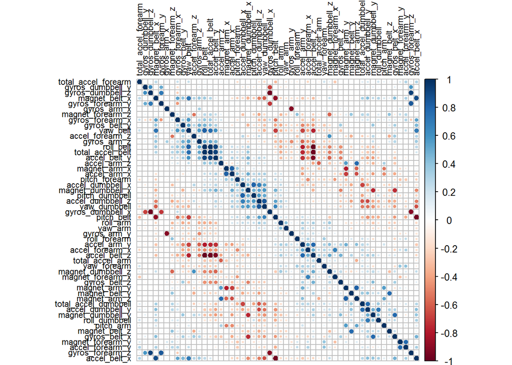

Indeed, our analysis demonstrates that some predictors are highly correlated with each other. So it might be a good idea to transform the data into principal components (i.e., build combinations of predictors that are uncorrelated and at the same time capture the most variance).

```r
preProc <- preProcess(data.training[, -classe_idx], method=c("pca"), thresh=0.99)
data.training.pca <- predict(preProc, data.training[,-classe_idx])
preProc
```

```
## Created from 19622 samples and 52 variables
##
## Pre-processing:
##   - centered (52)
##   - ignored (0)
##   - principal component signal extraction (52)
##   - scaled (52)
##
## PCA needed 36 components to capture 99 percent of the variance
```

The transformation keeps 36 principal components that capture 99% of variance.

## Step 3. Training prediction model

First, I split the preprocessed data into a training (70%) and validation data sets which will be used later for cross-validation checks. `Note`: For the sake of better interpretation and due to only marginal model accuracy improvement, I will use the full number of variables for prediction.

```r
set.seed(2314)
inTrain <- createDataPartition(data.training$classe, p=0.7, list=F)
training <- data.training[inTrain, ]
validation <- data.training[-inTrain,]
dim(training)
```

```
## [1] 13737    53
```

```r
dim(validation)
```

```
## [1] 5885   53
```

### Decision Trees

```r
set.seed(2433)
fitControl <- trainControl(method = "cv", number = 5)
modelFitDT <- train(classe~., method="rpart", trControl=fitControl, tuneLength = 10, data=training)
predictDT <- predict(modelFitDT, validation)
table(predictDT, validation$classe)
```

```
##
## predictDT    A    B    C    D    E
##         A 1519  256   51  129   75
##         B   46  613   94   50  159
##         C   31  120  815  144  115
##         D   63  104   65  598   80
##         E   15   46    1   43  653
```

```r
confusionMatrix(predictDT, validation$classe)$overall[1]
```

```
## Accuracy
## 0.713339
```

```r
1 - as.numeric(confusionMatrix(validation$classe, predictDT)$overall[1])
```

```
## [1] 0.286661
```

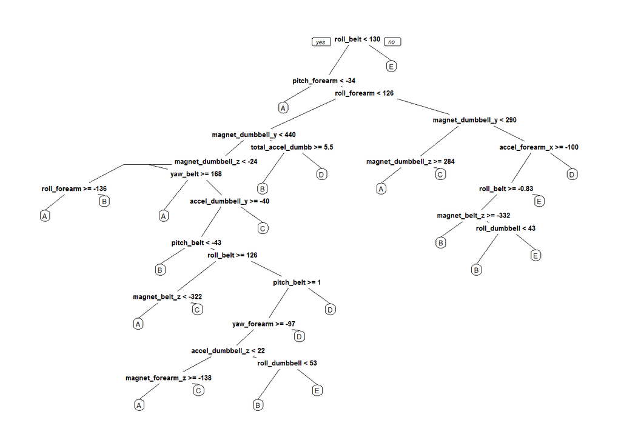

```r
# Alternatively
modFitDT <- rpart(classe ~ ., data=training, method="class")
prp(modFitDT)
```

The estimated accuracy of the Decision Tree Model is 71,33% and the estimated out-of-sample error is 28,67%. Let us check if we can achieve a better prediction by fitting a Random Forests model.

### Random Forests

I will use 200 trees, because I’ve noticed that the error rate doesn’t decline a lot after 200 trees, not necessarily resulting in a higher model accuracy.

```r
fitControl <- trainControl(method = "cv", number = 5)
modelFitRF <- train(classe~., method="rf", trControl=fitControl, ntree=200, data=training)
modelFitRF
```

```
## Random Forest
##
## 13737 samples
##    52 predictor
##     5 classes: 'A', 'B', 'C', 'D', 'E'
##
## No pre-processing
## Resampling: Cross-Validated (5 fold)
## Summary of sample sizes: 10990, 10989, 10991, 10989, 10989
## Resampling results across tuning parameters:
##
##   mtry  Accuracy   Kappa
##    2    0.9900268  0.9873834
##   27    0.9917014  0.9895013
##   52    0.9869690  0.9835150
##
## Accuracy was used to select the optimal model using the largest value.
## The final value used for the model was mtry = 27.
```

```r
predictRF <- predict(modelFitRF, validation)
table(predictRF, validation$classe)
```

```
##
## predictRF    A    B    C    D    E
##         A 1673   10    0    0    0
##         B    0 1127    3    1    2
##         C    1    2 1021   12    0
##         D    0    0    2  950    5
##         E    0    0    0    1 1075
```

```r
confusionMatrix(predictRF, validation$classe)$overall[1]
```

```
## Accuracy
## 0.993373
```

```r
1 - as.numeric(confusionMatrix(validation$classe, predictRF)$overall[1])
```

```
## [1] 0.006627018
```

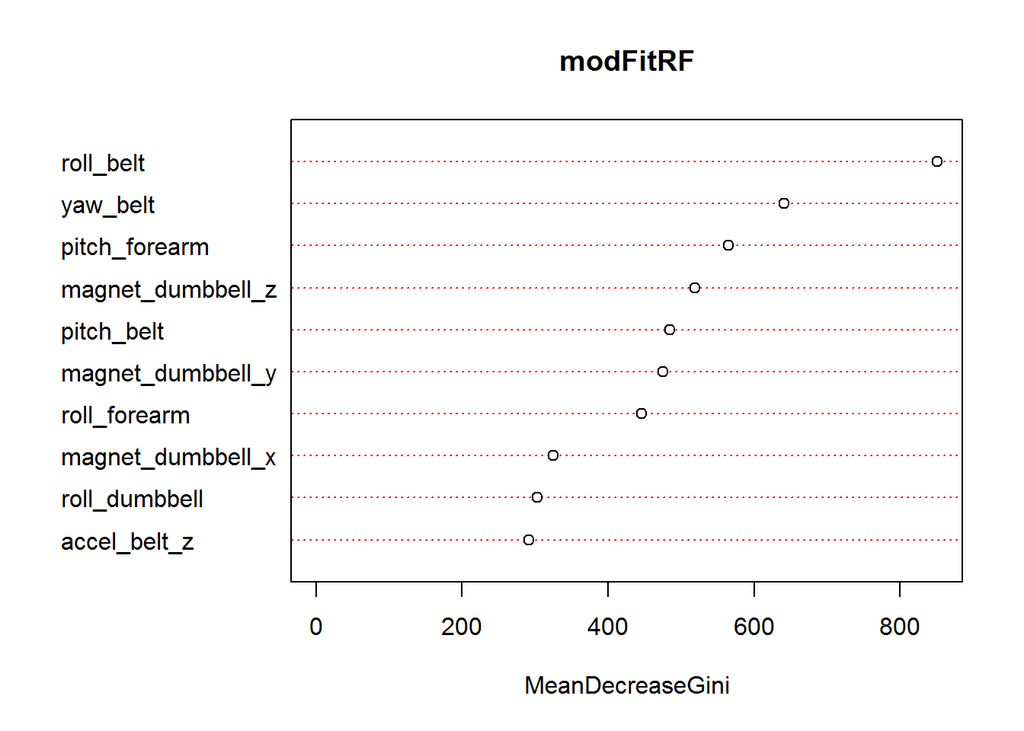

```r
# Alternatively
modFitRF <- randomForest(classe ~ ., data=training, method="class", ntree=200)
predictRF <- predict(modFitRF, validation, type = "class")

varImpPlot(modFitRF, n.var=10,pch = 21, gpch = 21, bg = par("bg"), color = par("fg"), gcolor = par("fg"), lcolor = "red")
```

### Support Vector Machines

```r
modelFitSVM <- svm(classe~., data=training, method="class")
predictSVM <- predict(modelFitSVM,validation, type="class")
table(predictSVM,validation$classe)
```

```
##
## predictSVM    A    B    C    D    E
##          A 1670   93    3    5    0
##          B    4 1008   29    0    4
##          C    0   37  975  110   16
##          D    0    0    7  846   26
##          E    0    1   12    3 1036
```

```r
confusionMatrix(predictSVM,validation$classe)$overall[1]
```

```
##  Accuracy
## 0.9405268
```

```r
1 - as.numeric(confusionMatrix(validation$classe, predictSVM)$overall[1])
```

```
## [1] 0.05947324
```

## Step 4. Prediction of the testing data set

Finaly, I apply the Random Forest model to the original testing data set downloaded from the data source. First remove the problem_id column.

```r
predict(modelFitRF, data.testing[, -length(names(data.testing))])
```

```
##  [1] B A B A A E D B A A B C B A E E A B B B
## Levels: A B C D E
```